# Stock-recruitment analysis for Atnarko sockeye

D. Greenberg

10/25/2022

The goal of this document is to examine stock-recruitment dynamics in Atnarko sockeye, using the historical time-series of recruitment for brood cohorts from 1972 to 2016.

We start by visualizing recruits as a function of spawner escapement, by brood year.

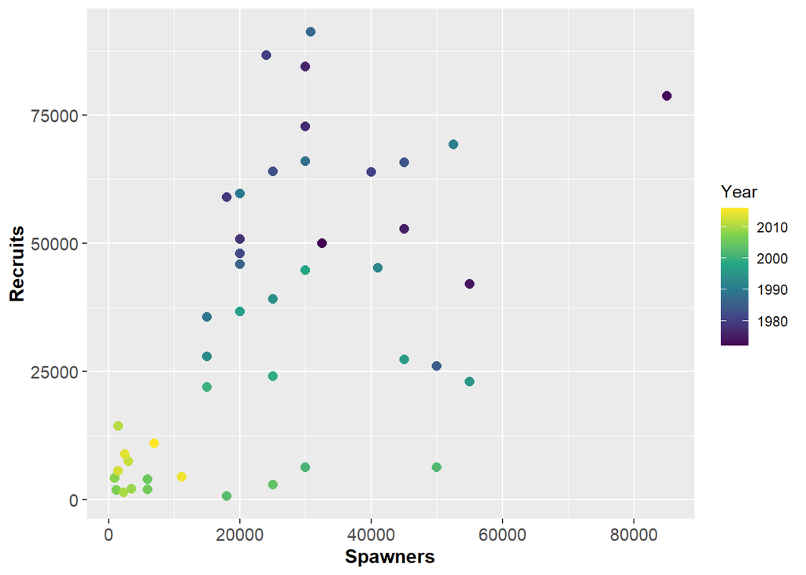

Figure 1. Recruitment as a function of spawner escapement for Atnarko sockeye from brood year cohorts 1972 to 2016.

## Model Selection

We will use the Atnarko sockeye stock-recruitment time-series to compare 8 different stock-recruitment model forms that represent time-invariant (models 1 & 2), time-varying (models 3 - 5), or regime-shift (models 6 - 8) model types. For the sake of brevity we will omit the finer details of these models - but by comparing these different forms we can ask whether the data best support either static stock-recruitment dynamics or non-stationary stock-recruitment dynamics in the form of either continuous changes in the parameters or through distinct shifts between stock regime states.

Model 1 - Static Ricker curve

Model 2 - Autocorrelated Ricker curve

Model 3 - Time-varying productivity Ricker curve

Model 4 - Time-varying capacity Ricker curve

Model 5 - Time-varying prod. & cap. Ricker curve

Model 6 - Regime-shift productivity Ricker curve

Model 7 - Regime-shift capacity Ricker curve

Model 8 - Regime-shift prod. & cap. Ricker curve

Using the out-of-sample log-likelihood estimates, we can compare the Bayesian model weights for each model set. First finding the highest likelhood prediction window (ie 1-year back parameters, last 3-year average of parameters, or last 5-year average of parameters). We can assess model weights using the full predictive dataset, or dropping the 10/20% of hardest to assess years as the full model likelihoods may be highly influenced by the most challenging to predict observations.

```
##    m1    m2    m3    m4    m5    m6    m7  m8_1
## 0.000 0.747 0.000 0.252 0.000 0.000 0.000 0.000
```

```
##    m1    m2    m3    m4    m5    m6    m7  m8_1
## 0.000 0.447 0.001 0.000 0.000 0.027 0.521 0.004
```

```
##    m1    m2    m3    m4    m5    m6    m7  m8_1
## 0.018 0.009 0.000 0.000 0.001 0.744 0.224 0.005
```

We’ll proceed by fitting and visualizing these three models to the full dataset.

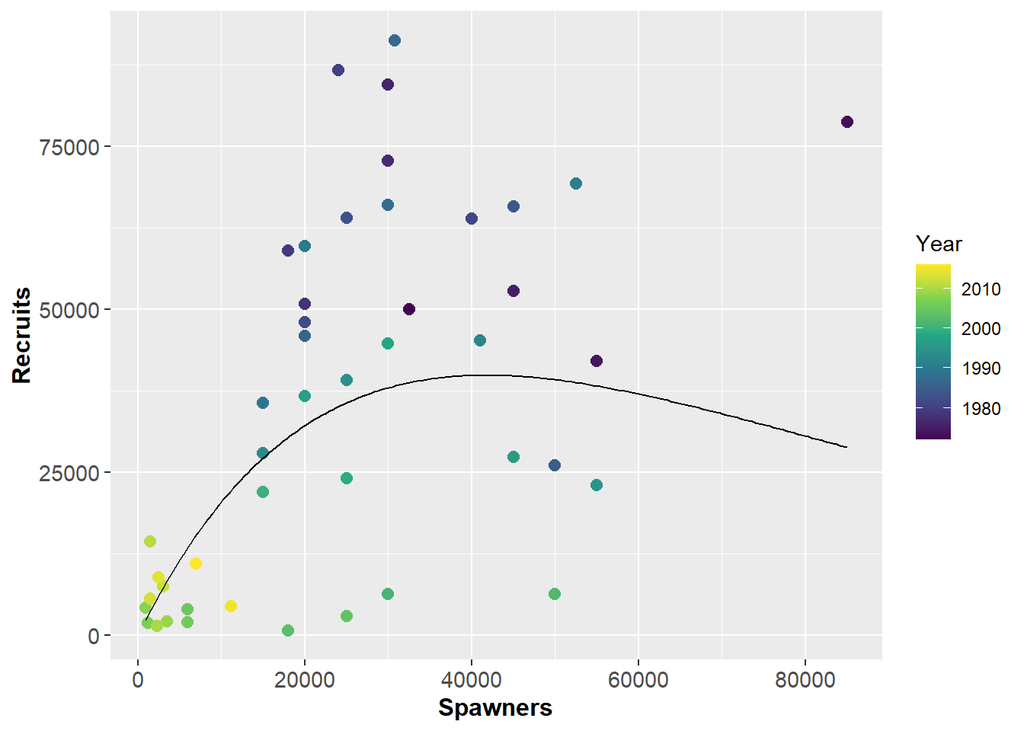

Autocorrelation of the residuals is moderate to high:

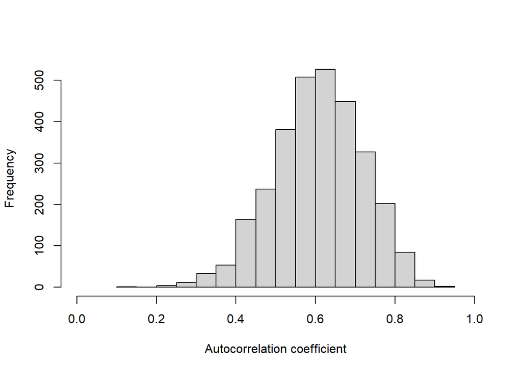

```
##    Min. 1st Qu.  Median    Mean 3rd Qu.    Max.
##  0.1223  0.5349  0.6105  0.6072  0.6867  0.9382
```

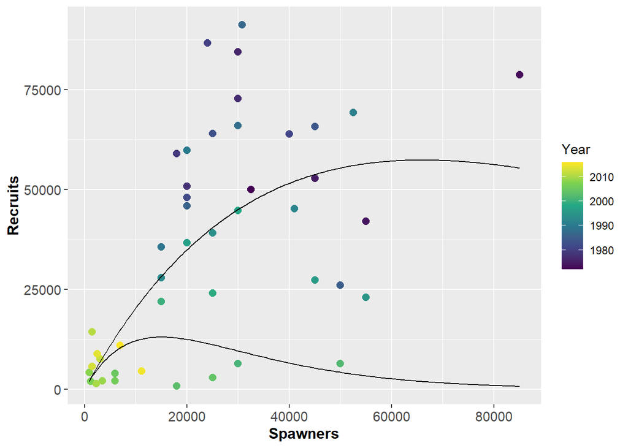

Figure 2b. Predicted stock-recruitment functions for Atnarko sockeye, with observations coloured by brood cohort year, from the top-rated model (regime-shift capacity) for the 90% highest log-likelihood years.

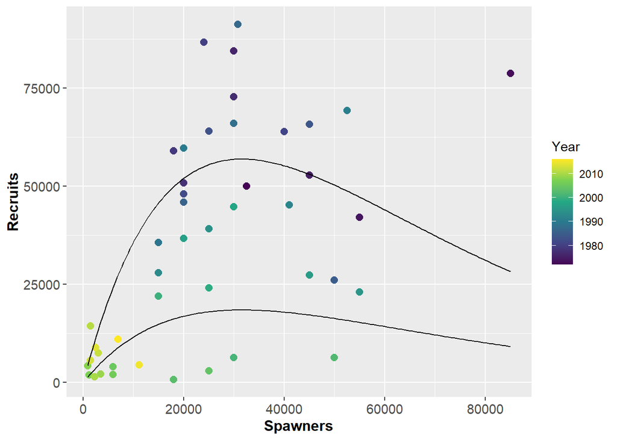

Figure 2c. Predicted stock-recruitment functions for Atnarko sockeye, with observations coloured by brood cohort year, from the top-rated model (regime-shift productivity) for the 80% highest log-likelihood years.

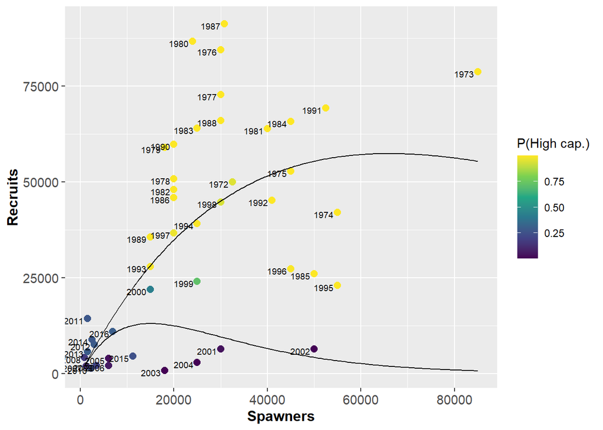

Figure 3a. Predicted stock-recruitment functions for Atnarko sockeye for each regime (high and low capacity regimes), with observations coloured by the median probability of being in the ‘High Capacity’ regime (Yellow indicating high probability and purple low probability, respectively).

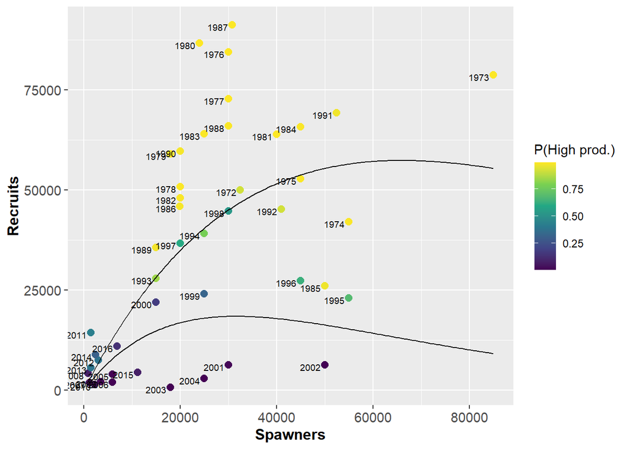

Figure 3b. Predicted stock-recruitment functions for Atnarko sockeye for each regime (high and low productivity regimes), with observations coloured by the median probability of being in the ‘High Productivity’ regime (Yellow indicating high probability and purple low probability, respectively).

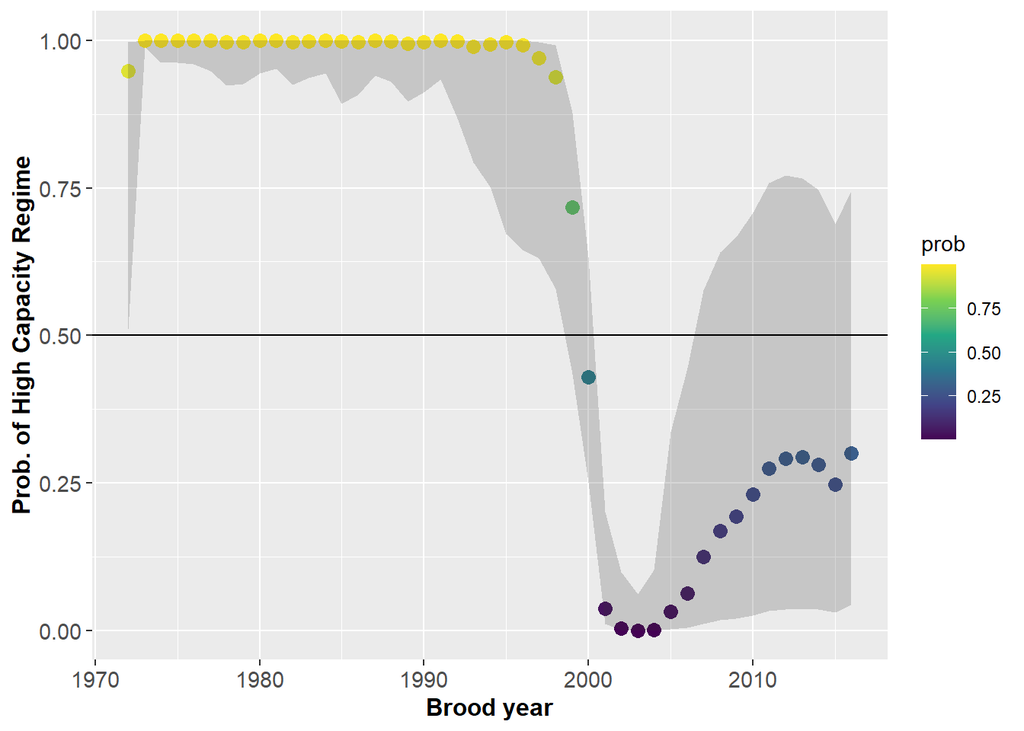

Figure 4a. Estimated probabilities of each brood year cohort being in the ‘high capacity’ regime state from 1972 to 2016, conversely, low probabilities indicate a high probability of being in a ‘low capacity’ regime state. Shaded area represents the 90% confidence intervals in the state probabilities.

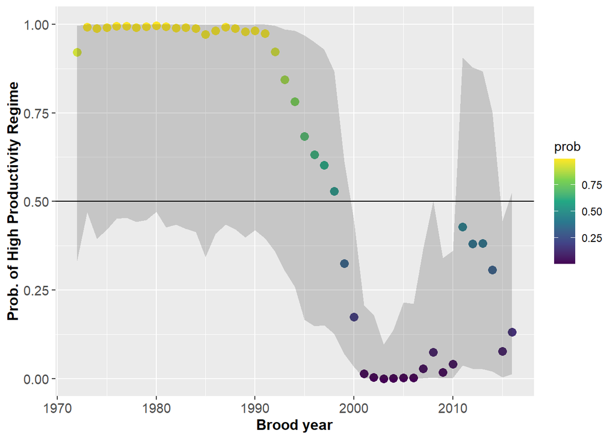

## Reference points

$S_{max}$: Histogram of the estimated spawner escapement that maximizes recruitment. Note that esitmates are truncated here (for visual purposes) at the 90% upper estimate to remove extremely high estimates on the tails of the parameters for each regime.

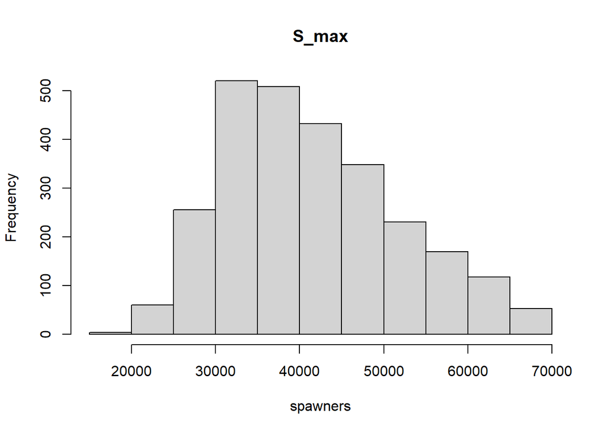

Figure 5a. Histogram corresponds to the top-ranked model (autocorrelated Ricker) for the full predictive samples from 1987 to 2016.

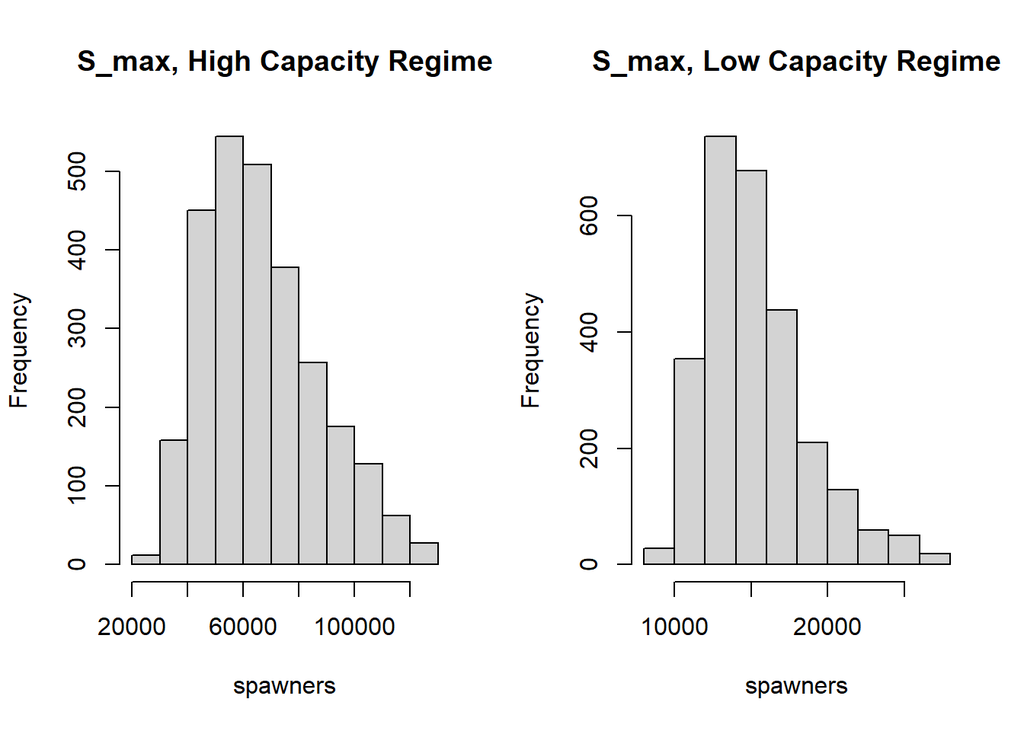

Figure 5b. This figure corresponds to the top-ranked model (regime-shift capacity) for the 90% highest predictive accuracy years - indicating the $S_{max}$ differences in each regime.

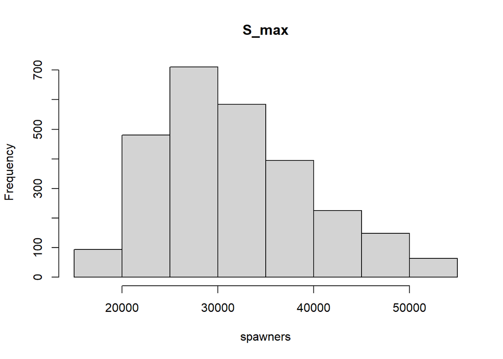

This figure corresponds to the top-ranked model (regime-shift productivity) for the 80% highest predictive accuracy years.

$S_{msy}$: Histogram of the estimated spawner escapement that would produce (theoretical) maximum sustainable yield (MSY). Note that esitmates are truncated here (for visual purposes) at the 90% upper estimate to remove extremely high estimates on the tails of the parameters for each regime.

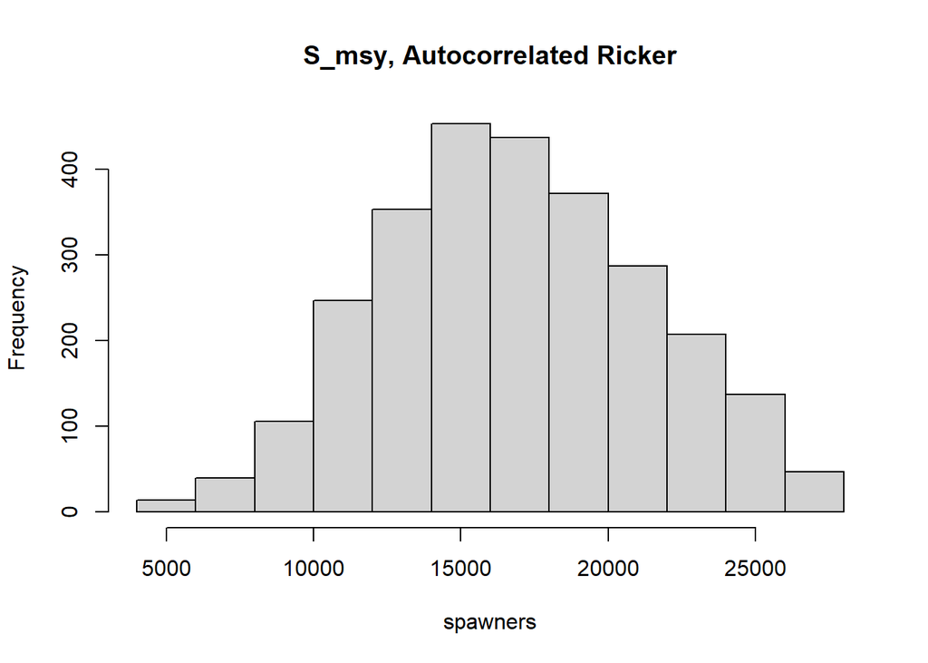

Figure 6a. This figure corresponds to the top-ranked model (autocorrelated Ricker) for the full predictive samples from 1987 to 2016.

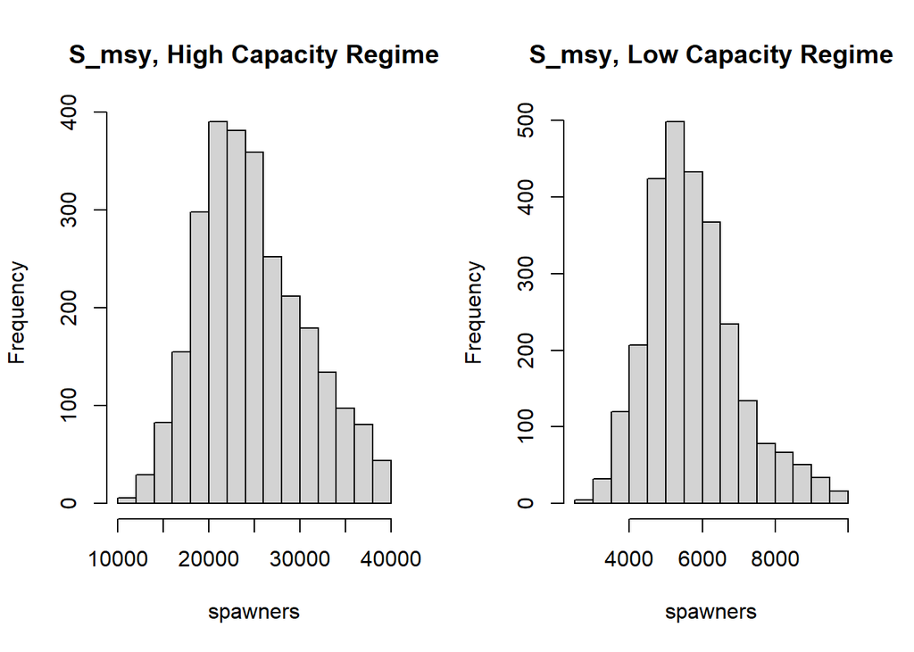

Figure 6b. This figure corresponds to the top-ranked model (regime-shift capacity) for the 90% highest predictive accuracy years - indicating the $S_{msy}$ differences in each regime.

[figure not shown]

$U_{msy}$: The corresponding maximum sustainable annual exploitation rate is shared between both regimes, since it depends on the shared productivity parameter.

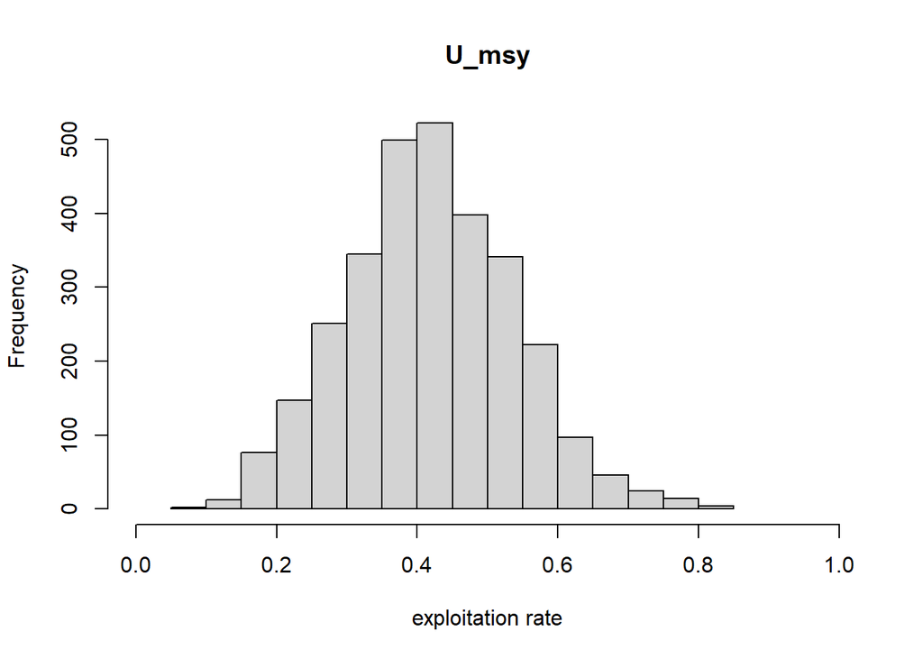

Figure 7a. This figure corresponds to $U_{msy}$ from the top-ranked model (autocorrelated static Ricker) for the full set of predictions from 1987 to 2016.

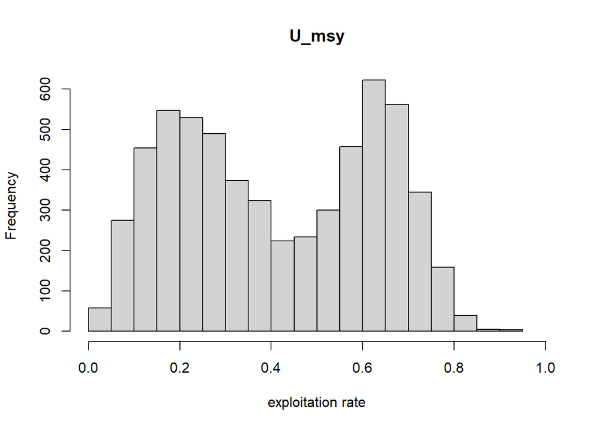

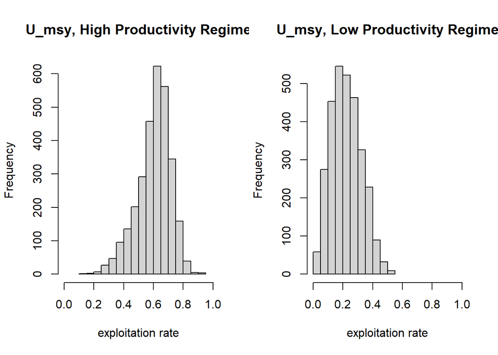

Figure 7c. This figure corresponds to $U_{msy}$ from the top-ranked model (regime-shift productivity) for the 80% highest predictive accuracy years - indicating the $U_{msy}$ differences in each regime.

## Ecosystem-level Covariates of Productivity

In this section, we will explore some ecosystem covariates that may have an influence on productivity in Atnarko sockeye.

To begin let’s visualize the annual deviations in productivity, $log(R/S)$, relative to the expectation from the static autocorrelated Ricker function for this stock:

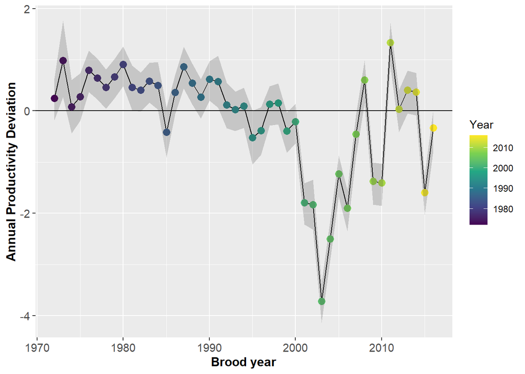

Figure 8. Annual deviations in productivity $log(R/S)$ through time.

Next let’s visualize some data on potential ecosystem-level drivers compiled by W. Atlas. These include:

1. Hatchery chum fry abundance - the number of chum fry released in the system lagged 2-years to reflect competition with sockeye juveniles with 1-year of freshwater rearing.
2. Pink salmon abundance - pink salmon abundance averaed over 2-3 winters where sockeye may be in competition at sea.
3. Sea surface temperature (SST) - annual SST anomalies sampled at the Pine Island lighthouse.
4. North Pacifc Gyre Oscillation (NPGO) index - NPGO during the 2nd winter of marine residency.

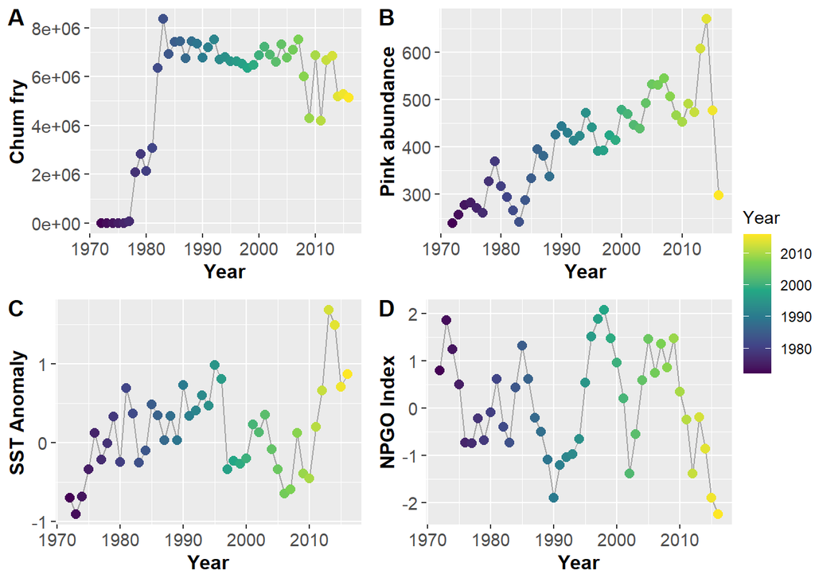

Figure 9. Trends in each ecosystem-level variable.

Let’s similarly visualize the productivity residuals against these various indices:

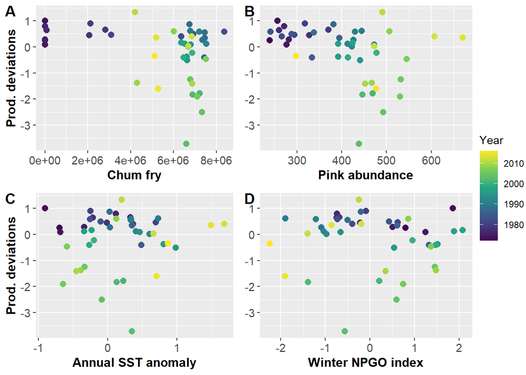

Figure 10. Annual deviations in productivity ($log(R/S)$) as a function of A) annual releases of chum fry, B) average abundance of pink salmon, C) annual sea surface temperature anomalies, and D) winter North Pacific Gyre Oscillation index.

The standardized linear effect size for each covariate, when included in the static autocorrelated Ricker model are as follows:

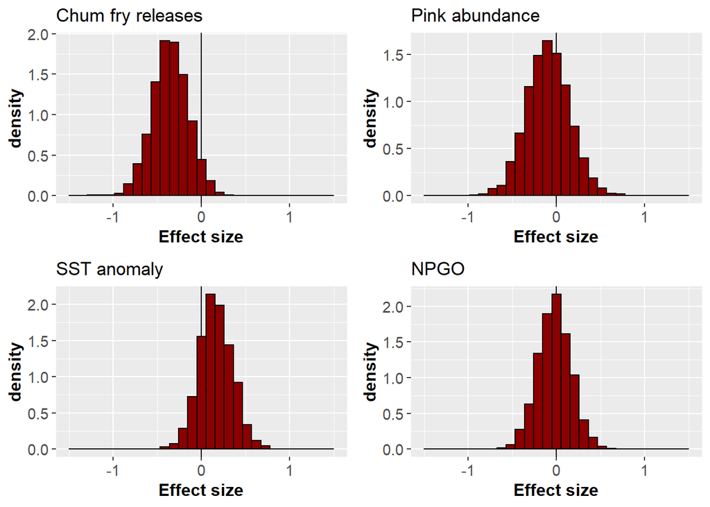

```
##     chum fry         pink abund            SST                NPGO
##  Min.   :-1.2622   Min.   :-0.93878   Min.   :-0.46921   Min.   :-0.77795
##  1st Qu.:-0.4904   1st Qu.:-0.25726   1st Qu.: 0.03866   1st Qu.:-0.15052
##  Median :-0.3515   Median :-0.09634   Median : 0.15575   Median :-0.02625
##  Mean   :-0.3530   Mean   :-0.09225   Mean   : 0.16267   Mean   :-0.02435
##  3rd Qu.:-0.2177   3rd Qu.: 0.06958   3rd Qu.: 0.28570   3rd Qu.: 0.10053
##  Max.   : 0.3269   Max.   : 0.76590   Max.   : 0.76714   Max.   : 0.74675
```